# Untitled-2

## 1. Framing the Problem

The goal of this report is to explore the relationship between median house value and other variables such as median income, population, and the number of households. Using linear regression, we aim to determine how each of these variables influences the median house value.

## 2. Getting the Data

The dataset used in this report can be found c:\Users\Ashu\Desktop\housing.csv. We will load it into a Pandas DataFrame for analysis.

```python
# Load necessary libraries
import pandas as pd

# Load the dataset
data = pd.read_csv('housing.csv')

# Display the first few rows of the dataset
data.head()
```

|  | longitude | latitude | housing_median_age | total_rooms | total_bedrooms | population | households | median_income | median_house_value | ocean_proximity |
| --- | --- | --- | --- | --- | --- | --- | --- | --- | --- | --- |
| 0 | -122.23 | 37.88 | 41.0 | 880.0 | 129.0 | 322.0 | 126.0 | 8.3252 | 452600.0 | NEAR BAY |
| 1 | -122.22 | 37.86 | 21.0 | 7099.0 | 1106.0 | 2401.0 | 1138.0 | 8.3014 | 358500.0 | NEAR BAY |
| 2 | -122.24 | 37.85 | 52.0 | 1467.0 | 190.0 | 496.0 | 177.0 | 7.2574 | 352100.0 | NEAR BAY |
| 3 | -122.25 | 37.85 | 52.0 | 1274.0 | 235.0 | 558.0 | 219.0 | 5.6431 | 341300.0 | NEAR BAY |
| 4 | -122.25 | 37.85 | 52.0 | 1627.0 | 280.0 | 565.0 | 259.0 | 3.8462 | 342200.0 | NEAR BAY |

## 3. Exploratory Data Analysis (EDA)

We will begin by exploring the statistics of the dataset and visualizing relationships between median house value and other independent variables.

```python
# Descriptive statistics
data.describe()
```

|  | longitude | latitude | housing_median_age | total_rooms | total_bedrooms | population | households | median_income | median_house_value |
| --- | --- | --- | --- | --- | --- | --- | --- | --- | --- |
| count | 20640.000000 | 20640.000000 | 20640.000000 | 20640.000000 | 20433.000000 | 20640.000000 | 20640.000000 | 20640.000000 | 20640.000000 |
| mean | -119.569704 | 35.631861 | 28.639486 | 2635.763081 | 537.870553 | 1425.476744 | 499.539680 | 3.870671 | 206855.816909 |
| std | 2.003532 | 2.135952 | 12.585558 | 2181.615252 | 421.385070 | 1132.462122 | 382.329753 | 1.899822 | 115395.615874 |
| min | -124.350000 | 32.540000 | 1.000000 | 2.000000 | 1.000000 | 3.000000 | 1.000000 | 0.499900 | 14999.000000 |
| 25% | -121.800000 | 33.930000 | 18.000000 | 1447.750000 | 296.000000 | 787.000000 | 280.000000 | 2.563400 | 119600.000000 |
| 50% | -118.490000 | 34.260000 | 29.000000 | 2127.000000 | 435.000000 | 1166.000000 | 409.000000 | 3.534800 | 179700.000000 |
| 75% | -118.010000 | 37.710000 | 37.000000 | 3148.000000 | 647.000000 | 1725.000000 | 605.000000 | 4.743250 | 264725.000000 |
| max | -114.310000 | 41.950000 | 52.000000 | 39320.000000 | 6445.000000 | 35682.000000 | 6082.000000 | 15.000100 | 500001.000000 |

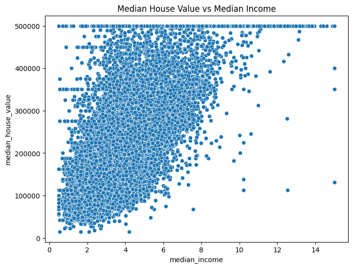

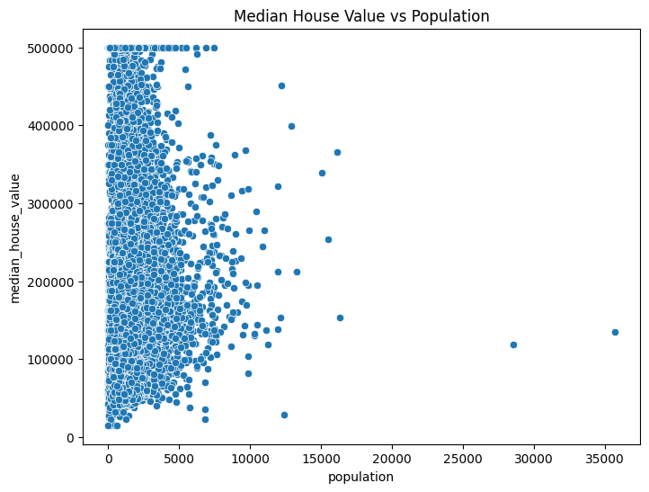

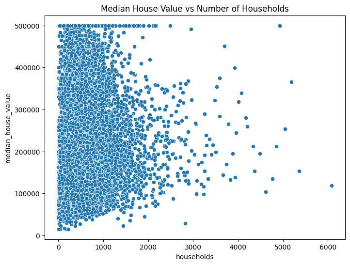

```python
# Import libraries for visualization
import seaborn as sns
import matplotlib.pyplot as plt

# Scatter plot of median house value vs. median income
plt.figure(figsize=(8, 6))
sns.scatterplot(x='median_income', y='median_house_value', data=data)
plt.title('Median House Value vs Median Income')
plt.show()

# Scatter plot of median house value vs. population
plt.figure(figsize=(8, 6))
sns.scatterplot(x='population', y='median_house_value', data=data)
plt.title('Median House Value vs Population')
plt.show()

# Scatter plot of median house value vs. number of households
plt.figure(figsize=(8, 6))
sns.scatterplot(x='households', y='median_house_value', data=data)
plt.title('Median House Value vs Number of Households')
plt.show()
```

### Textual Interpretation

- **Median Income**: As median income increases, the median house value tends to increase as well. This indicates a positive relationship.
- **Population**: The population seems to have a more scattered relationship with house value, showing no clear trend.
- **Number of Households**: There appears to be some positive correlation between the number of households and the median house value, but it's weaker than with income.

These insights will guide us as we conduct linear regressions to quantify these relationships.

The four variables in this analysis are:

1. **Median House Value**: The target variable representing house values.
2. **Median Income**: The average income in the area.
3. **Population**: The population in the area.
4. **Number of Households**: The total number of households in the area.

The range and characteristics of these variables show that income is more directly related to house values compared to population or households.

## Step 4 Running Linear Regression Code

```python
# Import library for linear regression
from sklearn.linear_model import LinearRegression
from sklearn.metrics import mean_squared_error, mean_absolute_error
from sklearn import linear_model

# Prepare independent and dependent variables
X_income = data[['median_income']]
X_population = data[['population']]
X_households = data[['households']]
y = data['median_house_value']

# Initialize the models
model_income = LinearRegression()
model_population = LinearRegression()
model_households = LinearRegression()

# Fit the models
model_income.fit(X_income, y)
model_population.fit(X_population, y)
model_households.fit(X_households, y)

# Predictions
y_pred_income = model_income.predict(X_income)
y_pred_population = model_population.predict(X_population)
y_pred_households = model_households.predict(X_households)
```

```python
# Create a table for the results
results = pd.DataFrame({
    'Model': ['Income vs House Value', 'Population vs House Value', 'Households vs House Value'],
    'Intercept': [model_income.intercept_, model_population.intercept_, model_households.intercept_],
    'Slope': [model_income.coef_[0], model_population.coef_[0], model_households.coef_[0]],
    'MSE': [
        mean_squared_error(y, y_pred_income),
        mean_squared_error(y, y_pred_population),
        mean_squared_error(y, y_pred_households)
    ],
    'MAE': [
        mean_absolute_error(y, y_pred_income),
        mean_absolute_error(y, y_pred_population),
        mean_absolute_error(y, y_pred_households)
    ]
})

# Display the results
results
```

|  | Model | Intercept | Slope | MSE | MAE |
| --- | --- | --- | --- | --- | --- |
| 0 | Income vs House Value | 45085.576703 | 41793.849202 | 7.011312e+09 | 62625.933791 |
| 1 | Population vs House Value | 210436.262076 | -2.511753 | 1.330741e+10 | 91153.820095 |
| 2 | Households vs House Value | 196928.577162 | 19.872775 | 1.325778e+10 | 90802.743243 |

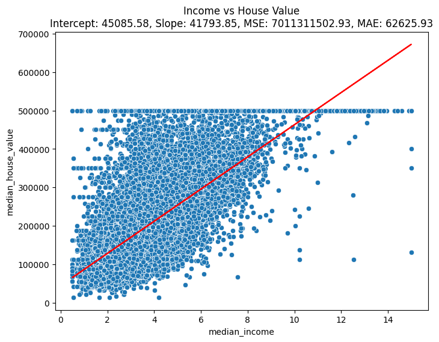

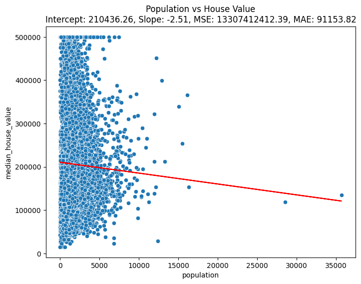

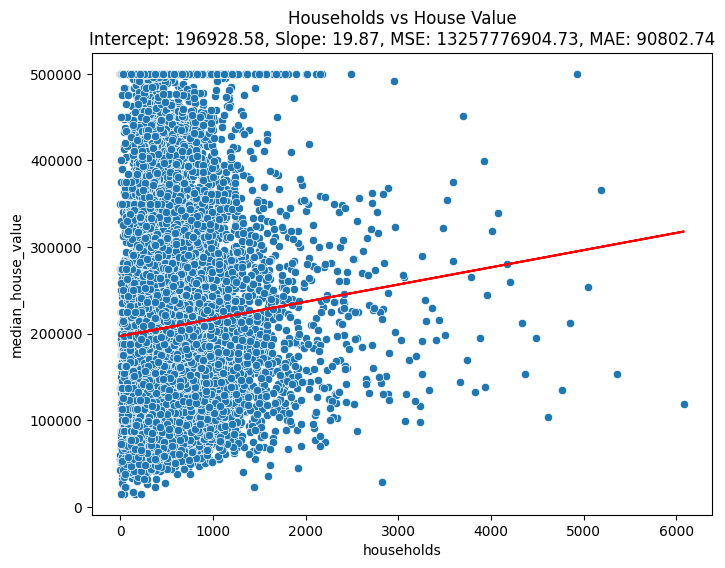

```python
# Plotting regression line for Income vs House Value
plt.figure(figsize=(8, 6))
sns.scatterplot(x='median_income', y='median_house_value', data=data)
plt.plot(X_income, y_pred_income, color='red')
plt.title(f'Income vs House Value\nIntercept: {model_income.intercept_:.2f}, Slope: {model_income.coef_[0]:.2f}, MSE: {mean_squared_error(y, y_pred_income):.2f}, MAE: {mean_absolute_error(y, y_pred_income):.2f}')
plt.show()

# Plotting regression line for Population vs House Value
plt.figure(figsize=(8, 6))
sns.scatterplot(x='population', y='median_house_value', data=data)
plt.plot(X_population, y_pred_population, color='red')
plt.title(f'Population vs House Value\nIntercept: {model_population.intercept_:.2f}, Slope: {model_population.coef_[0]:.2f}, MSE: {mean_squared_error(y, y_pred_population):.2f}, MAE: {mean_absolute_error(y, y_pred_population):.2f}')
plt.show()

# Plotting regression line for Households vs House Value
plt.figure(figsize=(8, 6))
sns.scatterplot(x='households', y='median_house_value', data=data)
plt.plot(X_households, y_pred_households, color='red')
plt.title(f'Households vs House Value\nIntercept: {model_households.intercept_:.2f}, Slope: {model_households.coef_[0]:.2f}, MSE: {mean_squared_error(y, y_pred_households):.2f}, MAE: {mean_absolute_error(y, y_pred_households):.2f}')
plt.show()
```

## 7. Summary .

Based on the three linear regression models:

- **Income vs House Value** has the strongest correlation with a significant positive relationship.
- **Population vs House Value** shows a weaker and more scattered trend.
- **Households vs House Value** has a positive but weaker correlation.

From these observations, the median income is the most significant factor in predicting house values. Population and the number of households play a smaller role.